# Part_iii_Classification

Yijun Zhou

4/24/2022

# OVERVIEW of A

Before using advanced methods, you need to develop a baseline understanding of the event probability as a function of the inputs using generalized linear modeling techniques. Use glm() to fit the following linear models: • Categorical variables only – linear additive • Continuous variables only – linear additive • All categorical and continuous variables – linear additive • Interact region with continuous inputs, do not include customer • Interact customer with continuous inputs, do not include region • All pairwise interactions of continuous inputs, do not include categorical inputs • 3 models with basis functions of your choice Can include interactions of the basis functions with other basis functions and with the categorical inputs! These models are consistent with the regression portion. Did you experience any issues or warnings while fitting the generalized linear models? Which of the 9 models is the best? What performance metric did you use to make your selection? Visualize the coefficient summaries for your top 3 models. How do the coefficient summaries compare between the top 3? Whichinputsseemimportant? ## load packages

```r
library(tidyverse)
library(caret)
```

```r
library(coefplot)
```

## read data set

```r
df_all <- readr::read_csv("final_project_train.csv", col_names = TRUE)
df_all <-df_all%>%select(-rowid,-response)%>% glimpse()
```

```
## Rows: 677
## Columns: 36
## $ region   <chr> "XX", "XX", "XX", "XX", "XX", "XX", "XX", "XX", "XX", "XX", "…
## $ customer <chr> "B", "B", "B", "B", "B", "B", "B", "B", "B", "B", "B", "B", "…
## $ xb_01    <dbl> 4.000000, 1.000000, 2.000000, 2.520000, 2.548387, 3.071429, 3…
## $ xb_02    <dbl> 4, 1, 2, 11, 6, 6, 10, 12, 9, 10, 8, 10, 10, 8, 6, 10, 13, 10…
## $ xb_03    <dbl> 4, 1, 2, -6, -1, 1, -4, -4, -2, -4, -2, -2, -2, -4, 1, -4, -3…
## $ xn_01    <dbl> 3.0000000, 2.0000000, 2.0000000, 1.5333333, 0.8387097, 1.8571…
## $ xn_02    <dbl> 3, 2, 4, 9, 3, 8, 6, 10, 10, 4, 6, 8, 9, 5, 7, 12, 12, 6, 6, …
## $ xn_03    <dbl> 3, 2, 0, -3, -4, -2, -5, -6, -3, -5, -3, -6, -4, -3, 0, -5, -…
## $ xa_01    <dbl> 12.000000, 3.000000, 9.000000, 7.080000, 6.451613, 6.857143, …
## $ xa_02    <dbl> 12, 3, 9, 29, 17, 18, 24, 27, 20, 19, 15, 24, 24, 15, 14, 26,…
## $ xa_03    <dbl> 12, 3, 9, -7, -2, 2, -9, -5, -3, -3, -1, 1, -2, -3, 3, -4, -5…
## $ xb_04    <dbl> 1.3333333, 1.0000000, 1.0000000, 0.8950476, 1.2247312, 1.1857…
## $ xb_05    <dbl> 1.3333333, 1.0000000, 1.0000000, -2.0000000, -0.5000000, 0.00…
```

[output cut: 23 more lines]

### explore the imbalance of data

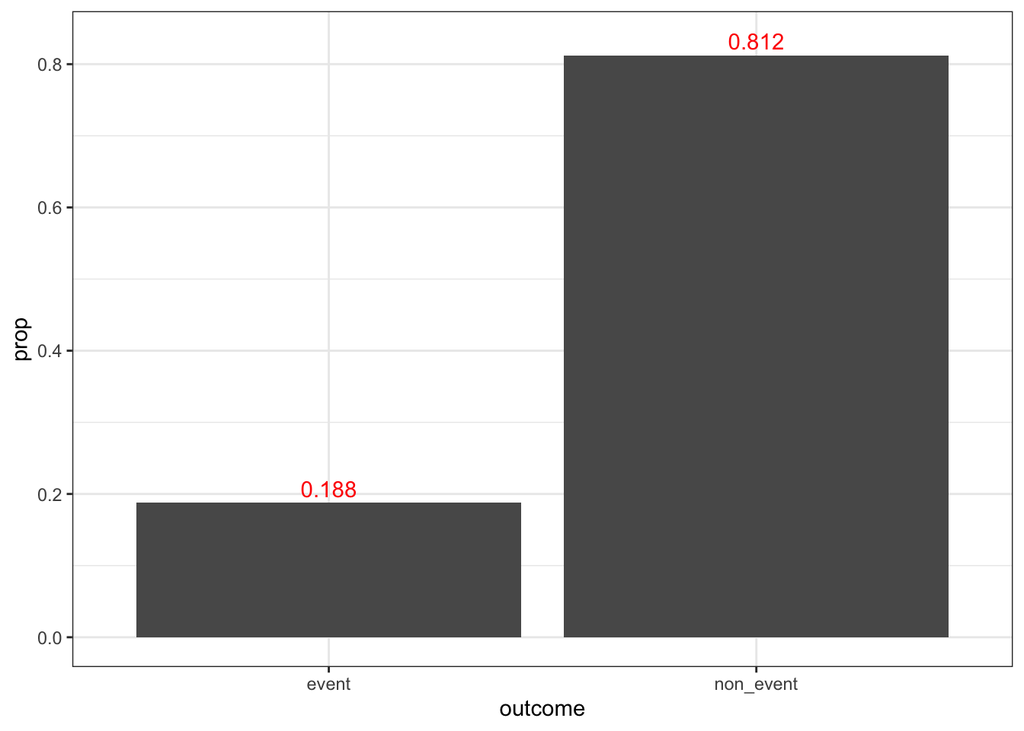

```r
df_all %>%
  ggplot(mapping=aes(x=outcome))+
  geom_bar(mapping=aes(y=stat(prop),group=1))+
  geom_text(data=df_all %>%count(outcome)%>%
              mutate(freq=n/sum(n)),
            mapping=aes(x=outcome,y=freq,label=signif(freq,3)),
            nudge_y=0.02,color='red')+
  theme_bw()
```

As we all know, if one class appears in less than 15% of the observations, we should be concerned about class imbalance. Based on the figure above, the “event” level is only 18% of the observations. It’s very close to 15%, in this part I’ll not deal with it.

```r
my_ctrl<-trainControl(method="repeatedcv",number=5,repeats=3,
                      summaryFunction=twoClassSummary,
                      classProbs=TRUE,
                      savePredictions = TRUE)
my_metric<-'ROC'
```

## Categorical variables only – linear additive

```r
set.seed(4321)
c_fit_glm_categorical_only <-train(outcome ~region+customer,
                            data=df_all,
                            method='glm',
                            metric=my_metric,
                            preProcess=c('center','scale'),
                            trControl=my_ctrl)
c_fit_glm_categorical_only
```

```
## Generalized Linear Model
##
## 677 samples
##   2 predictor
##   2 classes: 'event', 'non_event'
##
## Pre-processing: centered (10), scaled (10)
## Resampling: Cross-Validated (5 fold, repeated 3 times)
## Summary of sample sizes: 542, 542, 541, 542, 541, 542, ...
## Resampling results:
##
##   ROC        Sens         Spec
##   0.6024998  0.002564103  0.9981818
```

```r
c_fit_glm_categorical_only %>%readr::write_rds("c_fit_glm_categorical_only.rds")
```

## Continuous variables only – linear additive

```r
c_fit_glm_continuous_only <-train(outcome ~.,
                            data=df_all%>%select(-region,-customer),
                            method='glm',
                            metric=my_metric,
                            trControl=my_ctrl,
                            preProcess=c('center','scale'))
c_fit_glm_continuous_only
```

```
## Generalized Linear Model
##
## 677 samples
##  33 predictor
##   2 classes: 'event', 'non_event'
##
## Pre-processing: centered (33), scaled (33)
## Resampling: Cross-Validated (5 fold, repeated 3 times)
## Summary of sample sizes: 542, 541, 542, 542, 541, 542, ...
## Resampling results:
##
##   ROC        Sens       Spec
##   0.8199469  0.3673846  0.9406061
```

```r
c_fit_glm_continuous_only %>%readr::write_rds("c_fit_glm_continuous_only.rds")
```

## All categorical and continuous variables – linear additive

```r
c_fit_glm_all <-train(outcome ~.,
                    data=df_all,
                    method='glm',
                    metric=my_metric,
                    preProcess=c('center','scale'),
                    trControl=my_ctrl)
c_fit_glm_all
```

```
## Generalized Linear Model
##
## 677 samples
##  35 predictor
##   2 classes: 'event', 'non_event'
##
## Pre-processing: centered (43), scaled (43)
## Resampling: Cross-Validated (5 fold, repeated 3 times)
## Summary of sample sizes: 541, 541, 542, 542, 542, 542, ...
## Resampling results:
##
##   ROC        Sens       Spec
##   0.8355152  0.4361026  0.930303
```

```r
c_fit_glm_all %>%readr::write_rds("c_fit_glm_all.rds")
```

## Interact region with continuous inputs, do not include customer

```r
c_fit_glm_continuous_region <-train(outcome ~region*.,
                    data=df_all%>%select(-customer),
                    method='glm',
                    metric=my_metric,
                    preProcess=c('center','scale'),
                    trControl=my_ctrl)
c_fit_glm_continuous_region
```

```
## Generalized Linear Model
##
## 677 samples
##  34 predictor
##   2 classes: 'event', 'non_event'
##
## Pre-processing: centered (101), scaled (101)
## Resampling: Cross-Validated (5 fold, repeated 3 times)
## Summary of sample sizes: 541, 542, 541, 542, 542, 541, ...
## Resampling results:
##
##   ROC        Sens       Spec
##   0.7446443  0.3709744  0.8690909
```

```r
c_fit_glm_continuous_region %>%readr::write_rds("c_fit_glm_continuous_region.rds")
```

## Interact customer with continuous inputs, do not include region

```r
c_fit_glm_continuous_customer <-train(outcome ~customer*.,
                    data=df_all%>%select(-region),
                    method='glm',
                    metric=my_metric,
                    preProcess=c('center','scale'),
                    trControl=my_ctrl)
c_fit_glm_continuous_customer
```

```
## Generalized Linear Model
##
## 677 samples
##  34 predictor
##   2 classes: 'event', 'non_event'
##
## Pre-processing: centered (305), scaled (305)
## Resampling: Cross-Validated (5 fold, repeated 3 times)
## Summary of sample sizes: 541, 541, 542, 542, 542, 541, ...
## Resampling results:
##
##   ROC        Sens       Spec
##   0.6089744  0.4912821  0.7266667
```

```r
c_fit_glm_continuous_customer %>%readr::write_rds('c_fit_glm_continuous_customer.rds')
```

## All pairwise interactions of continuous inputs, do not include categorical inputs

```r
c_fit_glm_pairwise <-train(outcome ~(.)^2,
                    data=df_all%>%select(-region,-customer),
                    method='glm',
                    metric=my_metric,
                    preProcess=c('center','scale'),
                    trControl=my_ctrl)
c_fit_glm_pairwise
```

```
## Generalized Linear Model
##
## 677 samples
##  33 predictor
##   2 classes: 'event', 'non_event'
##
## Pre-processing: centered (561), scaled (561)
## Resampling: Cross-Validated (5 fold, repeated 3 times)
## Summary of sample sizes: 541, 542, 542, 542, 541, 542, ...
## Resampling results:
##
##   ROC        Sens       Spec
##   0.5200895  0.4887179  0.5533333
```

```r
c_fit_glm_pairwise %>%readr::write_rds('c_fit_glm_pairwise.rds')
```

## 3 models with basis functions of your choice

## first_model:the interaction between xw_02(which has the biggest difference while breaking up based on outcome) and all other continuous and categorical inputs

```r
c_fit_glm_xw2_interaction <-train(outcome~xw_02*.,
                                data=df_all,
                                method='glm',
                                metric=my_metric,
                                preProcess=c('center','scale'),
                                trControl=my_ctrl
                                )
c_fit_glm_xw2_interaction
```

```
## Generalized Linear Model
##
## 677 samples
##  35 predictor
##   2 classes: 'event', 'non_event'
##
## Pre-processing: centered (85), scaled (85)
## Resampling: Cross-Validated (5 fold, repeated 3 times)
## Summary of sample sizes: 542, 541, 541, 542, 542, 542, ...
## Resampling results:
##
##   ROC        Sens       Spec
##   0.8002928  0.4330256  0.8945455
```

```r
c_fit_glm_xw2_interaction %>%readr::write_rds('c_fit_glm_xw2_interaction.rds')
```

## second_model:the interaction between xw_02(which has the biggest difference while breaking up based on outcome) and other continuous inputs

```r
c_fit_glm_xw2_interaction_continuous <-train(outcome~xw_02*.,
                                data=df_all%>%select(-region,-customer),
                                method='glm',
                                metric=my_metric,
                                preProcess=c('center','scale'),
                                trControl=my_ctrl
                                )
c_fit_glm_xw2_interaction_continuous
```

```
## Generalized Linear Model
##
## 677 samples
##  33 predictor
##   2 classes: 'event', 'non_event'
##
## Pre-processing: centered (65), scaled (65)
## Resampling: Cross-Validated (5 fold, repeated 3 times)
## Summary of sample sizes: 542, 542, 541, 542, 541, 542, ...
## Resampling results:
##
##   ROC        Sens       Spec
##   0.8144531  0.4505641  0.9036364
```

```r
c_fit_glm_xw2_interaction_continuous %>%readr::write_rds('c_fit_glm_xw2_interaction_continuous.rds')
```

## third_model:the interaction between xs02 (which has the biggest difference while breaking up based on outcome) and other continuous inputs

```r
c_fit_glm_xs2_interaction_continuous <-train(outcome~xs_02*.,
                                data=df_all%>%select(-region,-customer),
                                method='glm',
                                metric=my_metric,
                                trControl=my_ctrl,
                                preProcess=c("center","scale")
                                )
c_fit_glm_xs2_interaction_continuous
```

```
## Generalized Linear Model
##
## 677 samples
##  33 predictor
##   2 classes: 'event', 'non_event'
##
## Pre-processing: centered (65), scaled (65)
## Resampling: Cross-Validated (5 fold, repeated 3 times)
## Summary of sample sizes: 542, 541, 541, 542, 542, 542, ...
## Resampling results:
##
##   ROC        Sens       Spec
##   0.7939049  0.3806154  0.8981818
```

```r
c_fit_glm_xs2_interaction_continuous%>%readr::write_rds('c_fit_glm_xs2_interaction_continuous.rds')
```

## These models are consistent with the regression portion. Did you experience any issues or warnings while fitting the generalized linear models?

Yes I met three kins of warnings.  
First Warning: glm.fit: fitted probabilities numerically 0 or 1 occurred  
Second Warning: glm.fit: algorithm did not converge  
Third Warning: Warning in predict.lm(object, newdata, se.fit, scale = 1, type = if (type == : prediction from a rank-deficient fit may be misleading  
For the first warning,  
it might mean the predicted probabilities of one or more observations are indistinguishable from 0 or 1. To solve this, there are two ways. The first one is increasing the sample size, and the second one is removing outliers.  
I tried to use preProcess method, and then the number of this kind of warning is decreasing, even some are still here.

For the second warning, it seems like the predictor variable is able to perfectly separate the response variable y into 0’s and 1’s, which answered by GOOGLE..To handle the warning, we can use penalized regression. For example, using “glmnet”.  
For the third warning, this might due to the fact that some pairs of predictor variables are perfectly correlated. It can be solved by tuning some inputs.

## Which of the 9 models is the best? What performance metric did you use to make your selection?

```r
results_ROC<-c(mod1_roc=c_fit_glm_categorical_only$results$ROC,
             mod2_roc=c_fit_glm_continuous_only$results$ROC,
             mod3_roc=c_fit_glm_all$results$ROC,
             mod4_roc=c_fit_glm_continuous_region$results$ROC,
             mod5_roc=c_fit_glm_continuous_customer$results$ROC,
             mod6_roc=c_fit_glm_pairwise$results$ROC,
             mod7_roc=c_fit_glm_xw2_interaction$results$ROC,
             mod8_roc=c_fit_glm_xw2_interaction_continuous$results$ROC,
             mod9_roc=c_fit_glm_xs2_interaction_continuous$results$ROC)
```

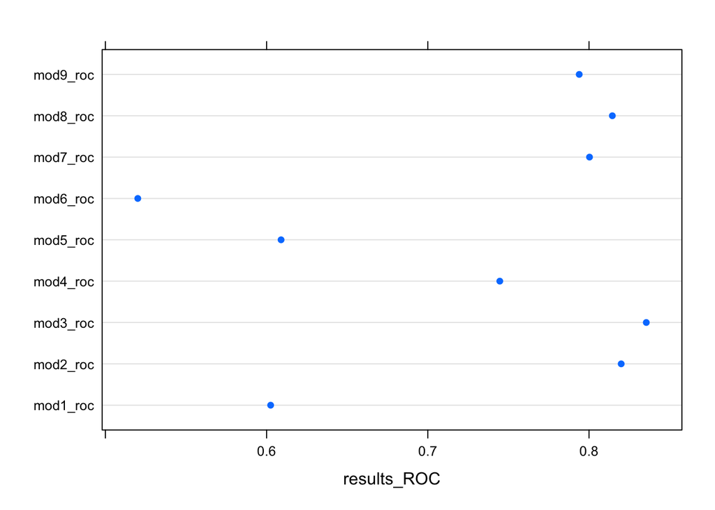

```r
dotplot(results_ROC)
```

```r
results_SENS<-c(mod1=c_fit_glm_categorical_only$results$Sens,
             mod2=c_fit_glm_continuous_only$results$Sens,
             mod3=c_fit_glm_all$results$Sens,
             mod4=c_fit_glm_continuous_region$results$Sens,
             mod5=c_fit_glm_continuous_customer$results$Sens,
             mod6=c_fit_glm_pairwise$results$Sens,
             mod7=c_fit_glm_xw2_interaction$results$Sens,
             mod8=c_fit_glm_xw2_interaction_continuous$results$Sens,
             mod9=c_fit_glm_xs2_interaction_continuous$results$Sens)
```

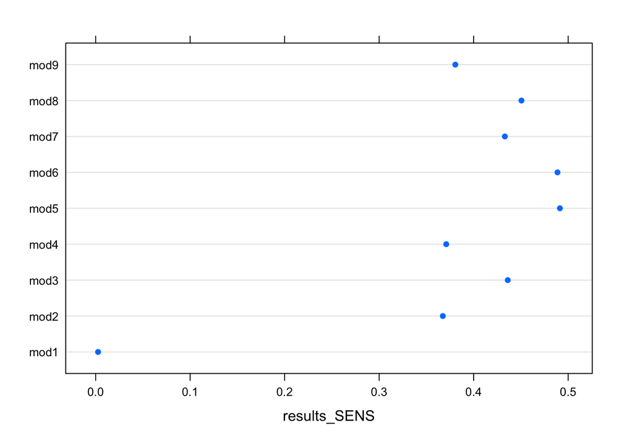

```r
dotplot(results_SENS)
```

```r
results_SPEC<-c(mod1=c_fit_glm_categorical_only$results$Spec,
             mod2=c_fit_glm_continuous_only$results$Spec,
             mod3=c_fit_glm_all$results$Spec,
             mod4=c_fit_glm_continuous_region$results$Spec,
             mod5=c_fit_glm_continuous_customer$results$Spec,
             mod6=c_fit_glm_pairwise$results$Spec,
             mod7=c_fit_glm_xw2_interaction$results$Spec,
             mod8=c_fit_glm_xw2_interaction_continuous$results$Spec,
             mod9=c_fit_glm_xs2_interaction_continuous$results$Spec)
```

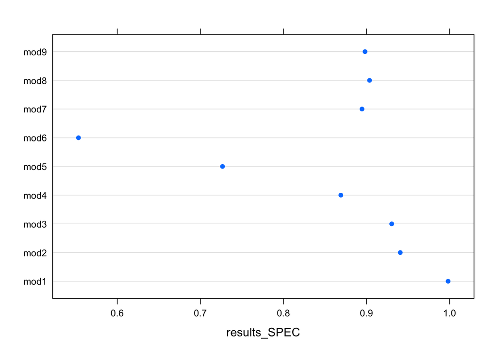

```r
dotplot(results_SPEC)
```

Based on the metric of ROC, model_3,model_2 and model_8 are the top three best models.

## Visualize the coefficient summaries for your top 3 models.

###model3

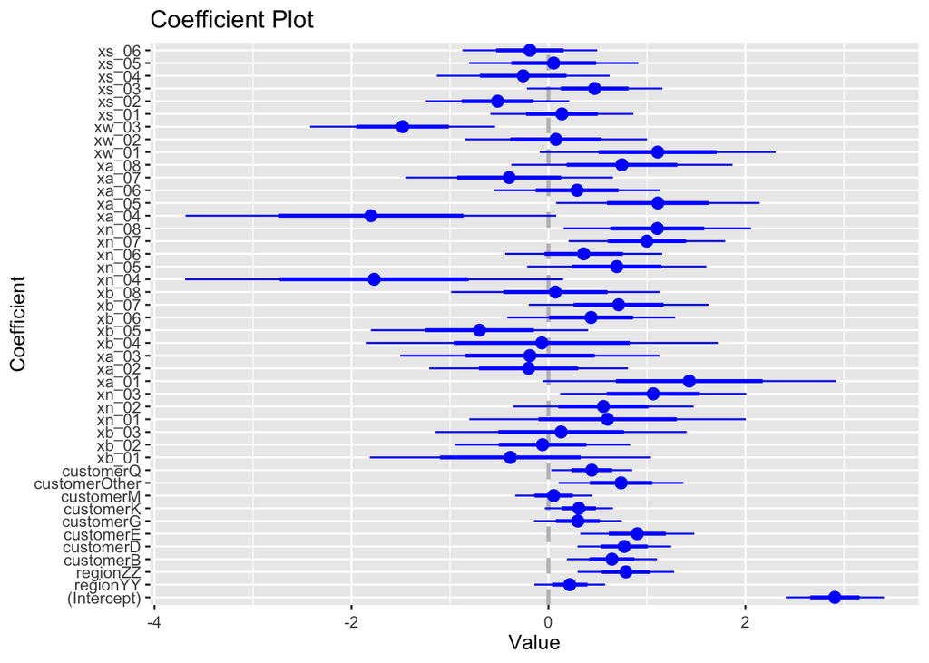

```r
coefplot(c_fit_glm_all)
```

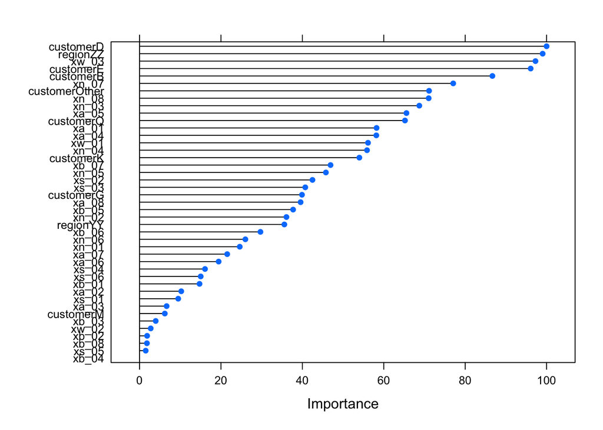

```r
plot(varImp(c_fit_glm_all))
```

### model2

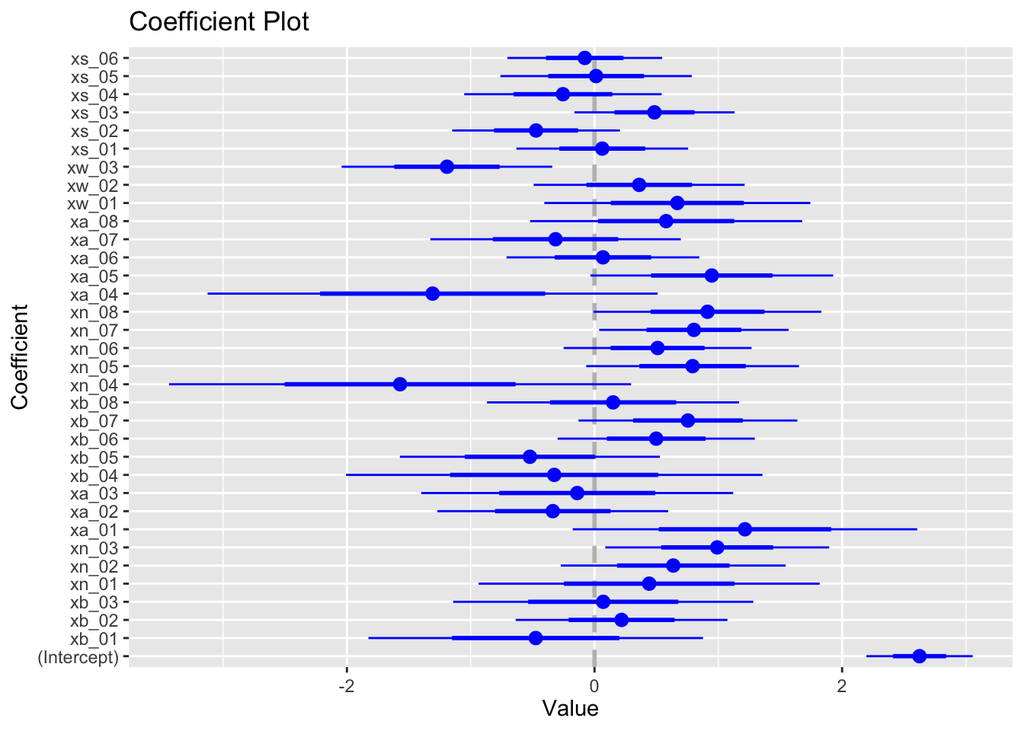

```r
coefplot(c_fit_glm_continuous_only)
```

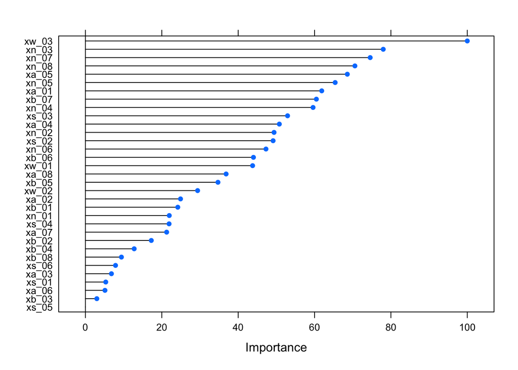

```r
plot(varImp(c_fit_glm_continuous_only))
```

### model8

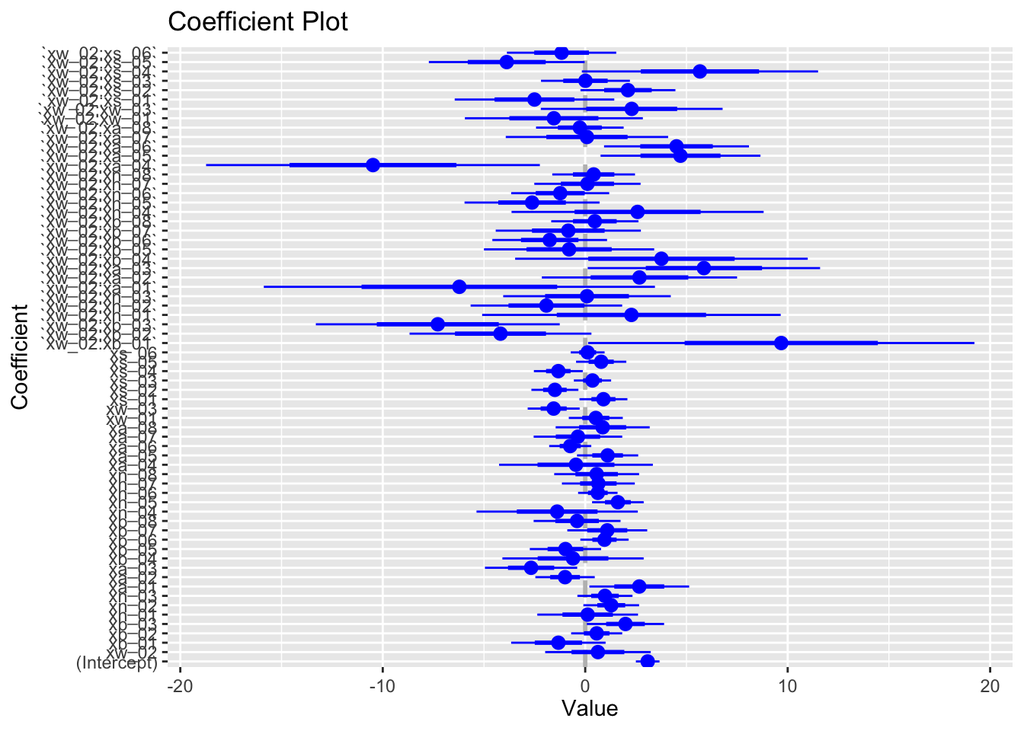

```r
coefplot(c_fit_glm_xw2_interaction_continuous)
```

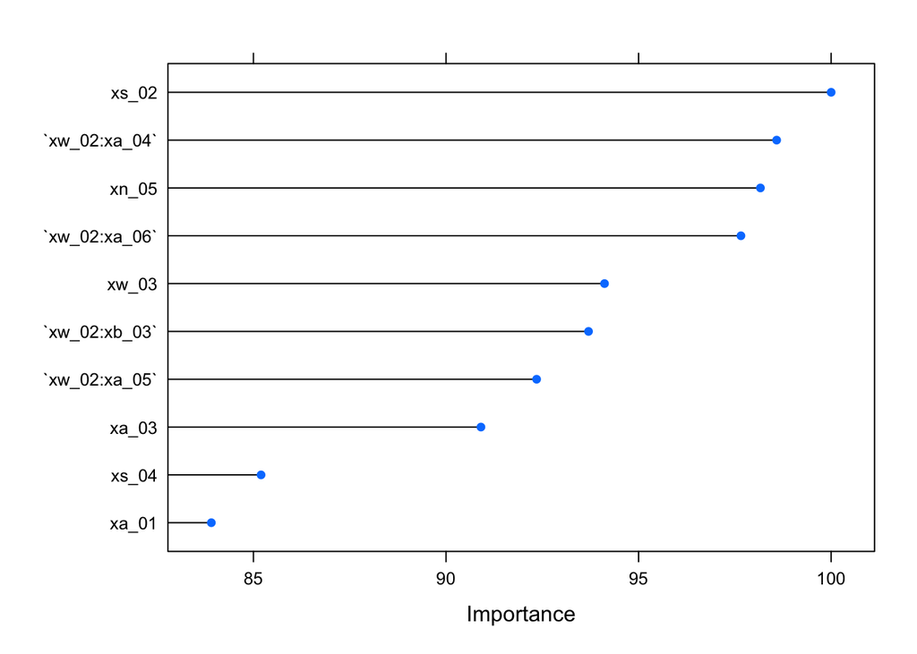

```r
varImp(c_fit_glm_xw2_interaction_continuous)%>%plot(top=10)
```

## How do the coefficient summaries compare between the top 3?

Based on the figures above, the conclusion is that model 3 is still the best model with more significant coefficients, while the number of significant coefficients of model 2 is less than it in model 3 and more than it in model 8. ## Which inputs seem important? Based on the figures above,  
for model3, inputs {xw03,customer,region} seem more important;  
for model2, inputs {xw03} seems most important; for model8, inputs {xs02} seems most important.  
In conclusion, categorical inputs{customer,region} and continuous inputs{xw03,xs02} are most important.